# H07 Stage 1: audit and analysis plan

Absolute latitude, photoperiod, collection period, and possible exposure plateaus

Published

August 7, 2026

**WarningHistorical Stage 1 gate and post-Stage 2 amendment**

This document originally reconstructed the signed H07 contract, the submitted V0 model and GAM-derivative workflow, all stated deviations, candidate inputs, and the pre-fit support and identifiability problem. Its evaluated cells create formula objects and descriptive design summaries only; this Stage 1 document does **not** fit an inferential model.

The owner approved the original gate as `H07-001` and later reopened its ceiling and support components after reviewing Stage 2. The post-result author revision is recorded as `H07-002`. Any computation-heavy bootstrap or simulation still requires a 50- or 100-replicate pilot, displayed runtime projection, and separate production approval.

# 1 How the revised ceiling question will be assessed

**ImportantH07-002: revised derivative-defined plateau assessment**

The owner has simplified the H07 question to whether a plateau-like photoperiod association is visible in the pooled observed data. For each of the nine metrics and each placement separately, the revised analysis:

1. uses the already fitted site- and participant-adjusted photoperiod GAM;
2. evaluates the first derivative of `s(photoperiod_hours)` at 100 equally spaced points from the exact metric-specific minimum to maximum recorded photoperiod;
3. identifies a pointwise detected increase when the derivative’s 95% interval is wholly above zero;
4. locates the first subsequent point whose interval contains zero; and
5. classifies a **derivative-defined plateau pattern** only when every later point remains compatible with zero through the maximum recorded photoperiod.

The primary implementation uses central finite differences, forward/backward differences at the observed boundaries, a 0.01 h step, and unconditional covariance where available. The exact V0 forward, conditional, pointwise settings are a method sensitivity. The transition is reported as the grid bracket between the final detected-increase point and the first zero-compatible point.

The pooled-support, one-hour, and leave-one-site-out rules no longer determine eligibility. They remain diagnostics describing which sites and collection periods contribute to different curve regions and how site omission changes the fitted association.

This rule was chosen after inspection of the Stage 2 support results and is therefore a post-result descriptive definition. Its pointwise intervals have no curve-wide or cross-metric multiplicity control. An interval containing zero does not demonstrate practical equivalence, so the classification is not proof of an asymptote, a mechanistic ceiling, or a causal photoperiod effect. Site, latitude, photoperiod, and collection period limitations remain explicit but do not suppress the requested classification.

The revised implementation incorporates H11’s computational lesson without assuming that H11’s method transfers to H07. H07 has 655–816 primary near-eye participant-days and 743–902 complementary chest participant-days per metric, not H11’s large half-hourly Gaussian/AR(1) problem. The proposed primary engine is therefore exact `mgcv::gam(method = "REML")`. No primary step requires `bam(discrete = FALSE)`. A checkpointed `mgcv::bam(method = "fREML", discrete = TRUE)` fit is only a computational fallback after a timed exact-fit attempt and must be checked against the exact GAM for fitted values, effective degrees of freedom, conditional AIC, supported predictions, and derivatives.

H11’s participant-cluster sandwich was validated for a Gaussian identity-link model after AR whitening. Its proposed family-aware extension to Tweedie is a new method, not an inherited result. H07 will use maintained `mgcv` inference as the primary conditional analysis and place any custom sandwich or participant-cluster refit bootstrap behind the H07-G7 method-validation pilot gate. Material residual dependence or failed identifiability prevents a confirmatory support claim until that gate is resolved.

# 2 Scope, terminology, and analytical boundary

H07 asks whether nine personal light-exposure metrics are associated with absolute latitude and civil photoperiod, whether the joint association is identifiable given the sites and collection periods, and whether any well-supported association can defensibly be called a plateau. The nine outcomes enter independently of H01 fitted results, p-values, or support classifications. H01 is used here only to reconstruct V0’s historical significance-dependent selection and to preserve the accepted metric and reporting terminology.

Near-eye measurement is primary. Chest measurement is complementary. Direct placement comparisons use the same participants and participant-days at both placements and retain separate models; placements are never pooled and no placement-equivalence claim is planned.

The predefined preparation sensitivity is the **gap-timing-unaware dataset**. It still passed the general 50%-per-hour and 80%-per-day coverage rules. The name means that the timing of the remaining missing observations was not used for an additional metric-specific adjustment; it does not mean that gaps, missingness, or coverage were ignored. For this one-time explanation, the primary could be interpreted as a time-sensitive primary metric dataset because its approved preparation uses the timing of remaining missing observations where relevant. From here onward it is called simply the **primary dataset**.

Reader-facing language uses **melEDI**, “period” rather than “bout,” and “bedside sleep-environment exposure” for the sleep metric. No temperature, weather, health outcome, clinical endpoint, unsupported predictor, causal effect, or physiological mechanism is introduced.

# 3 Registered H07 and decision provenance

## 3.1 Exact registered hypothesis

The signed preregistration states:

> **H7: There is a ceiling (nonlinear) effect of absolute latitude and photoperiod on level-, duration-, and exposure-history-based light metrics.**

The signed generic model is `Metric ~ te(Latitude, Photoperiod) + s(Site, bs="re") + s(Participant, bs="re")`. The supporting developed analysis plan repeats the same tensor-product GAMM and expressly notes that identifiability may be a problem when latitude and photoperiod are both present. The registration also places chest first, uses near-eye as a robustness repeat, requires FDR control within hypothesis families, and uses a two-AIC-point rule for GAMM model comparison. The approved placement decision now makes near eye primary and chest complementary; that reversal is disclosed rather than hidden.

```r
registered_h07_formula <- stats::as.formula(
  "Metric ~ te(Latitude, Photoperiod) + s(Site, bs = 're') + s(Participant, bs = 're')"
)
registered_h07_formula
```

```
Metric ~ te(Latitude, Photoperiod) + s(Site, bs = "re") + s(Participant,
    bs = "re")
```

## 3.2 Evidence and accepted decisions

Evidence and decisions controlling H07 Stage 1

| evidence | role |
| --- | --- |
| preregistration/AsPredicted #273407.pdf | Signed wording, tensor formula, placement, AIC, diagnostics, AR1, and FDR commitments |
| preregistration/Analysis_plan.docx | Developed plan and advance warning about latitude–photoperiod identifiability |
| _deviations.qmd | Registered removal of latitude, H01-dependent outcome selection, and revised photoperiod-only wording |
| audit/hypotheses/H05-H08_migration_map.md | Exact V0 reconstruction, defect map, proposed H07 repair, and major gates |
| audit/hypotheses/H03-H11_gated_workflow.qmd | Four-stage workflow and outcome-blinded Stage 1 boundary |
| audit/decisions/metric_validity.md | Admissible metric constructs and limitations |
| audit/decisions/metric_implementation_parameters.md | Support, gap, dose, window, and period implementation |
| audit/decisions/placement_decision.md | Near-eye primary, chest complementary, paired/common direct comparison |
| audit/decisions/site_display_conventions.md | Submitted site names, north-to-south order, and colours |
| audit/decisions/model_reporting.md | Exact samples, confidence intervals, diagnostics, and model provenance |
| audit/decisions/p_value_display.md | REPORT-008 three-decimal p-value presentation |
| RQ2.qmd; RQ2_chest.qmd; scripts/RQ2_specific.R | Executable V0 model selection and GAM-derivative implementation |
| docs/RQ2.html; docs/RQ2_chest.html | Rendered V0 retained-model tables and claims |
| audit/hypotheses/H11/02_inferential_method_amendment.qmd; audit/hypotheses/H11/02_inferential_method_decision.md; scripts/hypotheses/H11/h11_stage2.R | Accepted H11 replacement of unfinished ML/discrete-false fits by post-fit participant-cluster-robust whole-curve inference from one fREML/discrete model; methodological precedent only |
| manuscript/reviewer_comments_NatMed.rtf; audit/ledgers/reviewer_feedback_disposition.csv | Collection period, sparse site, placement, sample, multiplicity, and causal-language constraints |
| audit/hypotheses/H01/; audit/handoffs/H01_worker_handoff.md | Historical V0 selection dependency and accepted terminology only; no H01 fitted result selects H07 outcomes |

Scientific design calculations below use R 4.6.1. No H01 estimate or p-value enters outcome selection.

## 3.3 Registered and reconstructed deviations

H07 deviation and repair map

| component | registered_or_accepted | v0_or_legacy_change | Stage2_disposition |
| --- | --- | --- | --- |
| Outcome set | All nine level-, duration-, and exposure-history metrics | H01 photoperiod support selected eight near-eye and six chest candidates; H07 AIC then selected six and four | Fit all nine independently of H01; retain a reason-coded non-estimable row rather than shorten the family |
| Predictor surface | Tensor product of absolute latitude and photoperiod | Latitude was removed because the observed two-dimensional space was sparse | Attempt the registered tensor on exact metric rows; failure is non-identifiability, not permission for a ceiling claim |
| Placement | Chest main; near eye robustness | Separate near-eye and chest code paths | Approved near-eye primary, chest complementary, paired/common direct comparison |
| Response model | Metric-specific distribution not fully enumerated | Every metric used log10(value + 0.1) Gaussian GAM | Use the accepted metric-specific response family, transform, link, and common-family failure rule |
| Repeated days | Participant random effect | Participant random smooth, with no interpreted date-lag diagnostic | Explicit participant nested in site; interpret date-lag residual dependence |
| Model comparison | Two-AIC-point GAMM rule and FDR within H07 | Conditional delta-AIC was called significance; no nine-value p-vector | Retain audited conditional AIC as secondary relative-support evidence; use maintained approximate GAM tests in complete nine-value BH families; never call an AIC threshold significance |
| Plateau | Ceiling/nonlinear wording without an operational margin | Last pointwise-positive derivative boundary was treated as a ceiling | H07-002 applies a post-result positive-to-zero-compatible-through-the-end derivative rule; report only a descriptive derivative-defined pattern |
| Figures | Not specified | Daily mean duplicated and M10 omitted in both Fig14 assemblies | Address metrics by ID; show every intended panel once and persist exact source rows |

# 4 Exact V0 reconstruction

## 4.1 V0 formula objects and fitting rule

V0 filtered a global H01 result object by `H1_phot_sig` and metric category, then supplied the following exact formulas to `mgcv::bam()`. Both fits used `discrete = TRUE`, `method = "fREML"`, and ten threads. Every response was `log10(metric + 0.1)`, including durations with a point mass at zero.

```r
v0_h07_formulas <- list(
  H7_full = stats::as.formula(
    "log_zero_inflated(metric) ~ s(photoperiod) + s(site, bs = 're') + s(Id, bs = 're')"
  ),
  H7_null = stats::as.formula(
    "log_zero_inflated(metric) ~ s(site, bs = 're') + s(Id, bs = 're')"
  )
)

enframe(v0_h07_formulas, name = "formula_id", value = "formula") |>
  mutate(formula = map_chr(formula, h07_formula_text))
```

| formula_id | formula |
| --- | --- |
| H7_full | log_zero_inflated(metric) ~ s(photoperiod) + s(site, bs = "re") + s(Id, bs = "re") |
| H7_null | log_zero_inflated(metric) ~ s(site, bs = "re") + s(Id, bs = "re") |

V0 calculated `dAIC = AIC(full) - AIC(null)` and retained a model when `dAIC < -2`. This is a relative-support convention, not a significance test. For an `mgcv::gam` or `mgcv::bam` object, `AIC()` dispatches through `logLik.gam()` and uses the model’s conditional likelihood with effective degrees of freedom; it does **not** compare the stored fREML smoothing criterion. V0’s values are therefore potentially interpretable as conditional AIC evidence if the compared objects used identical response rows, family and link, weights, offset, likelihood implementation, and fitting engine, and if the smoothing-uncertainty-corrected `edf2` provenance can be verified. Those historical object-level checks are not currently documented, so V0 conditional AIC is classified as **provenance unverified**, not inherently invalid. Its outcome-selection dependence and “significant” label remain invalid.

## 4.2 Historical two-stage outcome selection and samples

Historical V0 H01-selected candidates and second-stage AIC retention

| Metric | Near eye — sample | Chest — sample | Near eye — retained | Chest — retained | Near eye — dAIC_display | Chest — dAIC_display |
| --- | --- | --- | --- | --- | --- | --- |
| Mean melEDI | 141 / 811 / 9 | 154 / 897 / 8 | Yes | Yes | -5.42 | -2.77 |
| Brightest 10 h mean | 141 / 811 / 9 | 154 / 897 / 8 | Yes | Yes | -4.26 | -2.57 |
| Darkest 10 h mean | 141 / 811 / 9 | NA | Yes | NA | -5.17 | NA |
| Time above 1,000 lx melEDI | 141 / 811 / 9 | 154 / 897 / 8 | Yes | No | -3.44 | — |
| Time above 250 lx melEDI during wake | 140 / 755 / 9 | 153 / 839 / 8 | No | No | — | — |
| Time below 10 lx melEDI before sleep | 141 / 780 / 9 | NA | No | NA | — | NA |
| Longest continuous period above 250 lx melEDI | 141 / 811 / 9 | 154 / 897 / 8 | Yes | Yes | -3.46 | -2.62 |
| melEDI dose | 141 / 811 / 9 | 154 / 897 / 8 | Yes | Yes | -6.56 | -5.48 |

Sample cells are participants / participant-days / sites. A dash means that H01 excluded the metric before H07 or H07 did not retain it. These historical fitted results are reconstructed only for comparison; they do not select the repaired H07 outcomes.

The near-eye screen began with eight metrics and retained six. The chest screen began with six and retained four. Time below 1 lx melEDI during sleep never entered either V0 candidate set. These nested result-dependent screens cannot define the repaired outcome family.

## 4.3 Exact V0 GAM-derivative method

The user correctly identified the derivative workflow as the substantive V0 method. The helper did not merely draw a smooth: it converted the final grid location with evidence of a positive derivative into the reported ceiling hour.

```r
v0_derivative_call <- quote(
  deriv <- gratia::derivatives(model, select = "s(photoperiod)")
)
v0_boundary_rule <- quote(
  deriv_signif <- deriv |>
    dplyr::filter(.lower_ci > 0) |>
    dplyr::slice_tail(n = 1)
)

v0_derivative_call
```

```
deriv <- gratia::derivatives(model, select = "s(photoperiod)")
```

```r
v0_boundary_rule
```

```
deriv_signif <- dplyr::slice_tail(dplyr::filter(deriv, .lower_ci >
    0), n = 1)
```

With the pinned V0 `gratia` 0.11.2 defaults, this means a 100-point grid, first-order forward finite differences with `eps = 1e-7`, 95% **pointwise** confidence intervals, conditional smoothing-parameter uncertainty, and no simultaneous curve control. `slice_tail()` selects the final positive- derivative point even if positive regions are separated rather than sustained.

Interpretation of the V0 derivative algorithm

| component | v0_setting | consequence |
| --- | --- | --- |
| Derivative target | s(photoperiod) only | No latitude derivative or joint-surface plateau was evaluated |
| Grid | n = 100 | The labelled hour depends on a software-generated grid |
| Finite difference | Forward; eps = 1e-7 | No stability check across difference rule or step size |
| Uncertainty | 95% pointwise confidence interval | Repeated grid-point inspection is uncontrolled |
| Boundary | Last row with lower CI > 0 | Marks the end of detected increase, not equivalence to zero |
| Sustained interval | None | A later increase, decrease, reversal, or edge loss can be mislabelled as flattening |
| Support guard | None | The boundary can occur where only sparse sites or collection periods remain |
| Influence | None | No leave-one-site-out stability requirement |

A non-significant derivative, an AIC threshold, and a visually flat smooth are each insufficient evidence of a ceiling.

V0 then described the last positive-derivative locations as ceilings around 14.7–16.4 h for level metrics and 16.6 h for time above 1,000 lx melEDI. The same near-eye and chest figure assembly duplicated daily mean and omitted M10. Every V0 threshold-hour and cross-placement ceiling claim is reopened.

# 5 Direct inputs, metric contract, and candidate samples

## 5.1 Input identities

Hash-verified direct H07 Stage 1 inputs

| Input | Path | SHA-256 prefix | Producer | R | Status |
| --- | --- | --- | --- | --- | --- |
| Primary near-eye participant-day metrics | artifacts/06_model_data/base/metrics_glasses_participant_day_enriched.rds | fc80f8a2a94a447c | scripts/pipeline/build_base_model_data.R | 4.6.1 | PASS |
| Complementary chest participant-day metrics | artifacts/06_model_data/base/metrics_chest_participant_day_enriched.rds | ce81c159fe018f35 | scripts/pipeline/build_base_model_data.R | 4.6.1 | PASS |
| Gap-timing-unaware participant-day metrics | artifacts/06_model_data/scenarios/manuscript_prepared_data/participant_day_metrics.rds | 28266064c6213eae | scripts/pipeline/build_manuscript_prepared_data.R | 4.6.1 | PASS |
| Site/date civil-photoperiod context | artifacts/06_model_data/context/site_solar_context.rds | b0e8de539572ee59 | scripts/pipeline/build_site_solar_context.R | 4.6.1 | PASS |

The Stage 1 render reads these files but does not write a shared model-data artifact.

## 5.2 Nine-metric response contract

All nine planned outcomes remain in scope even when a metric-specific model is non-estimable. Whole-day metrics describe the accepted hybrid measurement record, not uninterrupted 24-hour ocular exposure. The longest continuous period is an observed lower bound unless its boundaries are exactly identified. Corrected dose is available only when its relevance-support guard passes.

Proposed H07 outcome and response-family contract

| Order | Metric | Category | Unit | Prepared construct | Response model | Practical scale | Required diagnostic/sensitivity |
| --- | --- | --- | --- | --- | --- | --- | --- |
| 1 | Mean melEDI | Level based | lx | Daily geometric mean | Gaussian; log10(value + 0.1) | Ratio | Offset, influence, and upper-tail checks |
| 2 | Brightest 10 h mean | Level based | lx | Supported 10-hour window | Gaussian; log10(value + 0.1) | Ratio | Influence and upper-tail checks |
| 3 | Darkest 10 h mean | Level based | lx | Supported 10-hour window | Gaussian; log10(value + 0.1) | Ratio | High-risk exact-zero and residual checks |
| 4 | Time above 1,000 lx melEDI | Duration based | h | Full 24-hour cycle | mgcv::tw; log link; power estimated in [1.01, 1.99] | Ratio | Zero mass, dispersion, tail, and 24-hour prediction checks |
| 5 | Time above 250 lx melEDI during wake | Duration based | h | Waking near-eye measurement | mgcv::tw; log link; power estimated in [1.01, 1.99] | Ratio | Zero mass, tail, and waking-duration prediction checks |
| 6 | Time below 10 lx melEDI before sleep | Duration based | h | Three hours before attempted sleep | Gaussian; identity | Difference | Calendar-day cumulative duration with a six-hour audit threshold; identity-scale Gaussian selected by the H01 candidate assessment |
| 7 | Time below 1 lx melEDI during sleep | Duration based | h | Bedside sleep-environment measurement | mgcv::tw; log link; power estimated in [1.01, 1.99] | Ratio | Distribution and sleep-window prediction checks |
| 8 | Longest continuous period above 250 lx melEDI | Duration based | h | Observed lower bound | Gaussian; log10(value + 0.1) | Ratio | Mandatory exactly-identified-only sensitivity |
| 9 | melEDI dose | Exposure history based | lx·h | Time-sensitive missing-coverage correction | Gaussian; log10(value + 0.1) | Ratio | Offset, influence, and upper-tail checks |

The accepted H01/H05 family package is inherited for cross-hypothesis continuity, not selected from H07 results. A family or link failure opens one common predeclared replacement gate; it never triggers a result-specific switch.

## 5.3 Candidate-row construction

These are candidate complete-case frames before response transformation, design-rank checks, and model diagnostics. Stage 2 must persist the exact key of every fitted full/reduced pair; prepared counts cannot substitute for exact fitted samples.

## 5.4 Placement and preparation samples

Primary-dataset all-available candidate samples

| Metric | Near eye | Chest |
| --- | --- | --- |
| Mean melEDI | 141 / 816 / 9 | 154 / 902 / 8 |
| Brightest 10 h mean | 141 / 816 / 9 | 154 / 902 / 8 |
| Darkest 10 h mean | 141 / 816 / 9 | 154 / 902 / 8 |
| Time above 1,000 lx melEDI | 141 / 816 / 9 | 154 / 902 / 8 |
| Time above 250 lx melEDI during wake | 141 / 737 / 9 | 154 / 818 / 8 |
| Time below 10 lx melEDI before sleep | 139 / 655 / 9 | 153 / 743 / 8 |
| Time below 1 lx melEDI during sleep | 141 / 778 / 9 | 154 / 861 / 8 |
| Longest continuous period above 250 lx melEDI | 141 / 816 / 9 | 154 / 902 / 8 |
| melEDI dose | 141 / 761 / 9 | 154 / 851 / 8 |

Cells are participants / participant-days / sites. Near eye is primary; chest is complementary and not an unmatched direct placement comparison.

Gap-timing-unaware all-available candidate samples

| Metric | Near eye | Chest |
| --- | --- | --- |
| Mean melEDI | 141 / 811 / 9 | 154 / 897 / 8 |
| Brightest 10 h mean | 141 / 811 / 9 | 154 / 897 / 8 |
| Darkest 10 h mean | 141 / 811 / 9 | 154 / 897 / 8 |
| Time above 1,000 lx melEDI | 141 / 811 / 9 | 154 / 897 / 8 |
| Time above 250 lx melEDI during wake | 140 / 755 / 9 | 153 / 839 / 8 |
| Time below 10 lx melEDI before sleep | 141 / 780 / 9 | 154 / 867 / 8 |
| Time below 1 lx melEDI during sleep | 141 / 790 / 9 | 154 / 878 / 8 |
| Longest continuous period above 250 lx melEDI | 141 / 811 / 9 | 154 / 897 / 8 |
| melEDI dose | 141 / 811 / 9 | 154 / 897 / 8 |

Cells are participants / participant-days / sites. The same approved H07 implementation is applied; no result-dependent family or formula switch is allowed.

Paired/common candidates for separate near-eye and chest fits

| Metric | Primary dataset | Gap-timing-unaware dataset |
| --- | --- | --- |
| Mean melEDI | 112 / 643 / 8 | 112 / 640 / 8 |
| Brightest 10 h mean | 112 / 643 / 8 | 112 / 640 / 8 |
| Darkest 10 h mean | 112 / 643 / 8 | 112 / 640 / 8 |
| Time above 1,000 lx melEDI | 112 / 643 / 8 | 112 / 640 / 8 |
| Time above 250 lx melEDI during wake | 112 / 578 / 8 | 111 / 592 / 8 |
| Time below 10 lx melEDI before sleep | 110 / 505 / 8 | 112 / 615 / 8 |
| Time below 1 lx melEDI during sleep | 112 / 608 / 8 | 112 / 621 / 8 |
| Longest continuous period above 250 lx melEDI | 112 / 643 / 8 | 112 / 640 / 8 |
| melEDI dose | 112 / 598 / 8 | 112 / 640 / 8 |

Cells are paired participants / paired participant-days / sites. Both placement models use these exact keys for direct effect comparison; MPI has no chest data.

## 5.5 Metric-specific site support

**Near eye — primary**

Metric-specific primary near-eye candidate support by submitted site

| Metric | Borås (SE) | Delft (NL) | Dortmund (DE) | Tübingen (DE) | Munich (DE) | Madrid (ES) | Izmir (TR) | San José (CR) | Kumasi (GH) |
| --- | --- | --- | --- | --- | --- | --- | --- | --- | --- |
| Mean melEDI | 13 / 78 | 13 / 78 | 18 / 107 | 26 / 150 | 10 / 60 | 23 / 129 | 17 / 101 | 6 / 32 | 15 / 81 |
| Brightest 10 h mean | 13 / 78 | 13 / 78 | 18 / 107 | 26 / 150 | 10 / 60 | 23 / 129 | 17 / 101 | 6 / 32 | 15 / 81 |
| Darkest 10 h mean | 13 / 78 | 13 / 78 | 18 / 107 | 26 / 150 | 10 / 60 | 23 / 129 | 17 / 101 | 6 / 32 | 15 / 81 |
| Time above 1,000 lx melEDI | 13 / 78 | 13 / 78 | 18 / 107 | 26 / 150 | 10 / 60 | 23 / 129 | 17 / 101 | 6 / 32 | 15 / 81 |
| Time above 250 lx melEDI during wake | 13 / 73 | 13 / 64 | 18 / 90 | 26 / 141 | 10 / 54 | 23 / 113 | 17 / 94 | 6 / 30 | 15 / 78 |
| Time below 10 lx melEDI before sleep | 13 / 67 | 12 / 50 | 18 / 84 | 26 / 132 | 10 / 52 | 23 / 105 | 17 / 82 | 6 / 25 | 14 / 58 |
| Time below 1 lx melEDI during sleep | 13 / 76 | 13 / 68 | 18 / 95 | 26 / 150 | 10 / 60 | 23 / 118 | 17 / 99 | 6 / 31 | 15 / 81 |
| Longest continuous period above 250 lx melEDI | 13 / 78 | 13 / 78 | 18 / 107 | 26 / 150 | 10 / 60 | 23 / 129 | 17 / 101 | 6 / 32 | 15 / 81 |
| melEDI dose | 13 / 71 | 13 / 74 | 18 / 97 | 26 / 137 | 10 / 55 | 23 / 125 | 17 / 96 | 6 / 30 | 15 / 76 |

Cells are participants / participant-days. UCR has only six near-eye participants overall; sleep-, wake-, and dose-specific frames are smaller for several metrics.

**Chest — complementary**

Metric-specific complementary chest candidate support by submitted site

| Metric | Borås (SE) | Delft (NL) | Dortmund (DE) | Munich (DE) | Madrid (ES) | Izmir (TR) | San José (CR) | Kumasi (GH) |
| --- | --- | --- | --- | --- | --- | --- | --- | --- |
| Mean melEDI | 16 / 96 | 15 / 93 | 20 / 114 | 10 / 60 | 22 / 123 | 17 / 102 | 39 / 230 | 15 / 84 |
| Brightest 10 h mean | 16 / 96 | 15 / 93 | 20 / 114 | 10 / 60 | 22 / 123 | 17 / 102 | 39 / 230 | 15 / 84 |
| Darkest 10 h mean | 16 / 96 | 15 / 93 | 20 / 114 | 10 / 60 | 22 / 123 | 17 / 102 | 39 / 230 | 15 / 84 |
| Time above 1,000 lx melEDI | 16 / 96 | 15 / 93 | 20 / 114 | 10 / 60 | 22 / 123 | 17 / 102 | 39 / 230 | 15 / 84 |
| Time above 250 lx melEDI during wake | 16 / 89 | 15 / 79 | 20 / 98 | 10 / 54 | 22 / 111 | 17 / 95 | 39 / 211 | 15 / 81 |
| Time below 10 lx melEDI before sleep | 16 / 81 | 14 / 63 | 20 / 92 | 10 / 52 | 22 / 103 | 17 / 83 | 39 / 208 | 15 / 61 |
| Time below 1 lx melEDI during sleep | 16 / 92 | 15 / 83 | 20 / 102 | 10 / 60 | 22 / 115 | 17 / 100 | 39 / 225 | 15 / 84 |
| Longest continuous period above 250 lx melEDI | 16 / 96 | 15 / 93 | 20 / 114 | 10 / 60 | 22 / 123 | 17 / 102 | 39 / 230 | 15 / 84 |
| melEDI dose | 16 / 90 | 15 / 89 | 20 / 105 | 10 / 55 | 22 / 118 | 17 / 98 | 39 / 217 | 15 / 79 |

Cells are participants / participant-days. MPI is absent because no chest dataset exists for that site.

# 6 Predictor identifiability and collection-period support

## 6.1 Site, latitude, dates, and photoperiod

Collection periods and predictor support by placement and submitted site

| Site | Absolute latitude | Participants | Participant-days | Observed dates | Collection range | Photoperiod range |
| --- | --- | --- | --- | --- | --- | --- |
| Chest — complementary |  |  |  |  |  |  |
| Borås (SE) | 57.72° | 16 | 96 | 67 | 2025-03-04–2025-10-19 | 11.35–20.52 h (span 9.17) |
| Delft (NL) | 52.01° | 15 | 93 | 81 | 2025-02-22–2025-10-13 | 11.59–18.22 h (span 6.63) |
| Dortmund (DE) | 51.50° | 20 | 114 | 42 | 2025-06-11–2025-10-19 | 11.58–18.21 h (span 6.63) |
| Munich (DE) | 48.13° | 10 | 60 | 60 | 2024-05-14–2024-07-28 | 16.41–17.45 h (span 1.05) |
| Madrid (ES) | 40.42° | 22 | 123 | 71 | 2024-10-08–2025-02-09 | 10.33–12.35 h (span 2.02) |
| Izmir (TR) | 38.32° | 17 | 102 | 72 | 2024-12-24–2025-06-01 | 10.49–15.70 h (span 5.21) |
| San José (CR) | 9.94° | 39 | 230 | 73 | 2025-06-17–2025-09-06 | 12.96–13.47 h (span 0.52) |
| Kumasi (GH) | 6.68° | 15 | 84 | 84 | 2024-10-08–2025-02-01 | 12.49–12.71 h (span 0.22) |
| Near eye — primary |  |  |  |  |  |  |
| Borås (SE) | 57.72° | 13 | 78 | 61 | 2025-03-04–2025-10-12 | 11.90–20.52 h (span 8.63) |
| Delft (NL) | 52.01° | 13 | 78 | 66 | 2025-02-22–2025-09-27 | 11.59–18.22 h (span 6.63) |
| Dortmund (DE) | 51.50° | 18 | 107 | 43 | 2025-06-11–2025-10-19 | 11.58–18.22 h (span 6.64) |
| Tübingen (DE) | 48.52° | 26 | 150 | 60 | 2023-08-15–2023-11-12 | 10.50–15.53 h (span 5.03) |
| Munich (DE) | 48.13° | 10 | 60 | 60 | 2024-05-14–2024-07-28 | 16.41–17.45 h (span 1.05) |
| Madrid (ES) | 40.42° | 23 | 129 | 72 | 2024-10-08–2025-02-09 | 10.33–12.35 h (span 2.02) |
| Izmir (TR) | 38.32° | 17 | 101 | 72 | 2024-12-24–2025-06-01 | 10.49–15.70 h (span 5.21) |
| San José (CR) | 9.94° | 6 | 32 | 12 | 2025-06-17–2025-06-29 | 13.47–13.47 h (span 0.01) |
| Kumasi (GH) | 6.68° | 15 | 81 | 81 | 2024-10-08–2025-02-02 | 12.49–12.71 h (span 0.22) |

The first-to-last range does not imply uninterrupted sampling. Observed-date counts make sparse or separated collection periods visible.

Absolute latitude is one constant per site. Photoperiod is deterministically derived from site coordinates and local date. Thus site, latitude, season, and collection period are not independent design factors. Photoperiod varies within some sites, but UCR and KNUST cover almost no within-site range in the near-eye data, whereas northern sites cover much wider but different calendar periods.

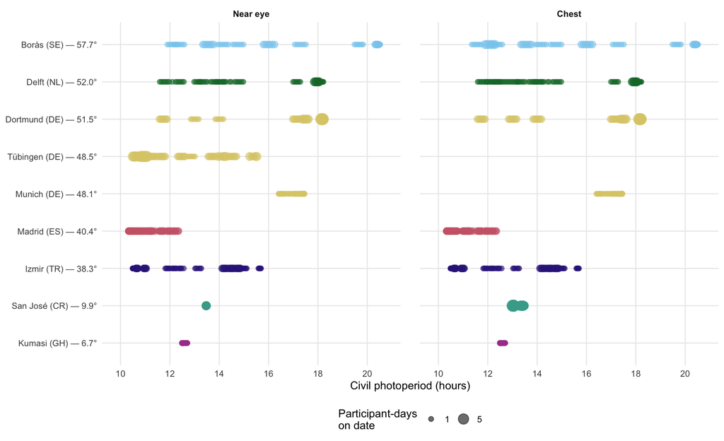

Figure 1: Observed civil-photoperiod support by submitted site and placement. Site labels include absolute latitude; point size represents participant-days on each observed local date.

## 6.2 Structural rank and overlap audit

Outcome-blinded linear design-rank audit

| Placement | Design | Columns | Rank | Deficiency |
| --- | --- | --- | --- | --- |
| Near eye | Site + photoperiod | 10 | 10 | 0 |
| Near eye | Site + latitude + photoperiod | 11 | 10 | 1 |
| Near eye | Latitude × photoperiod | 4 | 4 | 0 |
| Chest | Site + photoperiod | 9 | 9 | 0 |
| Chest | Site + latitude + photoperiod | 10 | 9 | 1 |
| Chest | Latitude × photoperiod | 4 | 4 | 0 |

The site-plus-latitude design is rank deficient because latitude is exactly determined by site. A penalized random-site tensor may return a fit, but software convergence alone cannot separate site from latitude.

Photoperiod overlap across sites

| Placement | Sites | All-site common lower | All-site common upper | All-site common width | Pairwise overlap | Median positive overlap |
| --- | --- | --- | --- | --- | --- | --- |
| Near eye | 9 | 16.41 h | 12.35 h | -4.06 h | 28 / 36 | 1.05 h |
| Chest | 8 | 16.41 h | 12.35 h | -4.06 h | 21 / 28 | 1.00 h |

A negative all-site width means that no photoperiod interval is observed at every site. Pairwise overlap does not create local replication of latitude because each latitude still belongs to one site.

The registered tensor therefore combines nine latitude stripes rather than a dense two-dimensional design. A fitted tensor can borrow smoothness across empty regions, but those interpolations are not observations. The high- photoperiod edge is especially vulnerable to northern-site and collection- period leverage.

## 6.3 Metric-specific upper-tail support

Primary near-eye support at each metric’s upper photoperiod decile

| Metric | Upper-decile threshold | Participants | Participant-days | Sites | Sites represented |
| --- | --- | --- | --- | --- | --- |
| Mean melEDI | 18.08 h | 14 | 82 | 3 | Borås (SE); Delft (NL); Dortmund (DE) |
| Brightest 10 h mean | 18.08 h | 14 | 82 | 3 | Borås (SE); Delft (NL); Dortmund (DE) |
| Darkest 10 h mean | 18.08 h | 14 | 82 | 3 | Borås (SE); Delft (NL); Dortmund (DE) |
| Time above 1,000 lx melEDI | 18.08 h | 14 | 82 | 3 | Borås (SE); Delft (NL); Dortmund (DE) |
| Time above 250 lx melEDI during wake | 18.13 h | 14 | 76 | 3 | Borås (SE); Delft (NL); Dortmund (DE) |
| Time below 10 lx melEDI before sleep | 18.12 h | 14 | 66 | 3 | Borås (SE); Delft (NL); Dortmund (DE) |
| Time below 1 lx melEDI during sleep | 18.07 h | 14 | 78 | 3 | Borås (SE); Delft (NL); Dortmund (DE) |
| Longest continuous period above 250 lx melEDI | 18.08 h | 14 | 82 | 3 | Borås (SE); Delft (NL); Dortmund (DE) |
| melEDI dose | 18.04 h | 17 | 77 | 3 | Borås (SE); Delft (NL); Dortmund (DE) |

The upper decile is a descriptive edge-support audit, not a plateau threshold. Participant-days repeat within participants and do not substitute for independent sites.

# 7 Revised derivative estimand and the H07-002 decision

## 7.1 Association estimand

For metric (m), let μₘ(ℓ, p) be the population response-scale mean from the registered tensor at absolute latitude ℓ and photoperiod (p), with site and participant random effects set to zero. The primary registered association estimand is the joint contribution of the latitude–photoperiod tensor over the observed metric-specific support, conditional on the registered random effects. It is evaluated by a complete nine-metric model-evidence package:

1. the maintained `summary.gam()` approximate whole-term test of the complete latitude–photoperiod tensor, assembled into the `H07-F1-registered-association` BH family;
2. a prespecified approximate nested `anova.gam()` comparison of the tensor against its bilinear latitude-by-photoperiod subspace, assembled into the `H07-F3-registered-nonlinear-shape` BH family;
3. conditional AIC differences for the full-versus-null and full-versus-bilinear candidate pairs as secondary relative-support evidence, never as p-values; and
4. response-scale predicted surfaces and directional partial derivatives with 95% uncertainty only where the design-support rule permits them.

The tests are conditional, approximate GAM inference and not participant-cluster-robust by construction. They are released only if the registered tensor is identifiable and residual dependence is not materially inconsistent with the fitted participant random effect. The nested shape test also requires identical response rows, weights, offsets, family/link, and fitting method; a genuinely nested coefficient space; and greater effective degrees of freedom in the tensor model. Failure of any condition makes the affected p-value non-estimable rather than prompting a favourable alternative.

The exact REML tensor, null, and bilinear models are fitted on one locked metric-specific frame. `AIC()` is audited as `mgcv` conditional AIC, including whether `edf2` is available, and the historical two-point convention is reported only as a descriptive relative-support label. The association test asks whether the tensor term is zero; the shape comparison asks whether the supported linear-predictor surface requires more than a bilinear form. Because every approved link is monotone, a constant linear predictor is also a constant response mean, but a bilinear linear predictor need not be bilinear after back-transformation. Practical estimates and derivatives are therefore reported on the response scale. None of these procedures establishes a plateau.

If the tensor is non-identifiable, a separately approved photoperiod-only smooth can estimate a narrower, adapted association conditional on site. It does not become the registered H07 result and cannot identify a latitude effect.

## 7.2 Derivative-defined plateau estimand

V0 evaluated the first derivative of the photoperiod smooth. H07-002 retains that direction and defines the requested visible plateau pattern for metric $m$ and placement $q$ on a 100-point metric-specific grid. Let $d_{mq}(p)$ be the first derivative of the fitted `s(photoperiod_hours)` component on its model scale and let $[L_{mq}(p), U_{mq}(p)]$ be its pointwise 95% interval. A derivative-defined plateau pattern is present when:

1. at one grid point, $L_{mq}(p) > 0$, indicating a pointwise detected increase;
2. the immediately following grid point has $L_{mq}(p) \leq 0 \leq U_{mq}(p)$; and
3. every later grid point through the exact maximum recorded photoperiod also has an interval containing zero.

The transition is interval-censored by the grid and is reported as the bracket between the final detected-increase point and the first zero-compatible point. A later pointwise detected increase or decrease makes the rule fail. No minimum tail length, site-overlap threshold, or leave-one-site-out stability requirement is imposed.

## 7.3 Equivalence and terminology boundary

No accepted source supplies a minimum practically important remaining slope for any of the nine heterogeneous metrics. H07-002 intentionally replaces the former equivalence estimand with a pointwise non-detection rule. Instrument resolution, model standard errors, a percentage chosen for convenience, and the two-AIC-point rule still cannot supply an equivalence margin.

Metric-specific equivalence-margin audit

| Metric | Practical derivative scale | External or scientific margin | H07-002 disposition |
| --- | --- | --- | --- |
| Mean melEDI | Response ratio per photoperiod hour (lx) | Not available | Assess a descriptive derivative-defined pattern |
| Brightest 10 h mean | Response ratio per photoperiod hour (lx) | Not available | Assess a descriptive derivative-defined pattern |
| Darkest 10 h mean | Response ratio per photoperiod hour (lx) | Not available | Assess a descriptive derivative-defined pattern |
| Time above 1,000 lx melEDI | Response ratio per photoperiod hour (h) | Not available | Assess a descriptive derivative-defined pattern |
| Time above 250 lx melEDI during wake | Response ratio per photoperiod hour (h) | Not available | Assess a descriptive derivative-defined pattern |
| Time below 10 lx melEDI before sleep | Difference per photoperiod hour (h) | Not available | Assess a descriptive derivative-defined pattern |
| Time below 1 lx melEDI during sleep | Response ratio per photoperiod hour (h) | Not available | Assess a descriptive derivative-defined pattern |
| Longest continuous period above 250 lx melEDI | Response ratio per photoperiod hour (h) | Not available | Assess a descriptive derivative-defined pattern |
| melEDI dose | Response ratio per photoperiod hour (lx·h) | Not available | Assess a descriptive derivative-defined pattern |

The revised pointwise rule is not an equivalence test. An interval containing zero does not show that the remaining slope is scientifically negligible.

**ImportantH07-002 interpretation**

Stage 2 may report that a metric does or does not meet the requested **derivative-defined plateau pattern**. Because the decision is based on pointwise non-detection and was adopted after viewing Stage 2 output, it must remain labelled descriptive and post-result. It must not be translated into proof that the derivative is zero, a biological maximum has been reached, or the association generalizes independently of site and collection period.

## 7.4 Former sustained-support rule: diagnostic only

The original H07-001 design-support rule was defined from predictor geometry and outcome availability without examining metric values. It required:

1. evaluate a 0.1 h photoperiod grid;
2. a site contributes at a grid point only when the point lies within that metric/site’s 5th–95th photoperiod percentiles and the ±0.5 h local window contains at least five participants and 15 participant-days;
3. a pooled point requires at least three sites, 20 participants, 60 participant-days, and no site contributing more than 50% of local days;
4. the pooled rule must still pass after removal of every site; and
5. a sustained interval requires at least 1.0 continuous h of eligible grid points.

H07-002 removes these thresholds as eligibility conditions. Their calculations are retained below to document cross-site overlap and upper-tail composition; they no longer censor the derivative grid or determine the revised plateau classification.

Outcome-blinded diagnostic application of the former support rule

| Metric | Pooled eligible grid range | LOSO-stable grid range | LOSO-stable interval ≥1.0 h |
| --- | --- | --- | --- |
| Mean melEDI | 10.6–11.0 h | None | None |
| Brightest 10 h mean | 10.6–11.0 h | None | None |
| Darkest 10 h mean | 10.6–11.0 h | None | None |
| Time above 1,000 lx melEDI | 10.6–11.0 h | None | None |
| Time above 250 lx melEDI during wake | 10.6–11.0 h | None | None |
| Time below 10 lx melEDI before sleep | 10.6–11.0 h | None | None |
| Time below 1 lx melEDI during sleep | 10.6–11.0 h | None | None |
| Longest continuous period above 250 lx melEDI | 10.6–11.0 h | None | None |
| melEDI dose | 10.6–11.0 h | None | None |

Only missing-versus-available outcome status and predictor geometry are used. H07-002 retains this result as a limitation display, not an eligibility gate for the revised derivative classification.

The primary near-eye design does not pass the former cross-site LOSO rule. Under H07-002 this shows that the upper curve cannot be interpreted as a site-replicated photoperiod response; it does not prevent asking whether the requested pattern is visible in the pooled fitted association.

# 8 Exact proposed model objects — no fits

## 8.1 Response construction and identifiers

Stage 2 will create `response_value` before fitting:

- `log10(value + 0.1)` for daily mean, M10, L10, longest period, and corrected dose, fitted with a Gaussian family;
- the natural non-negative value for the three Tweedie-log duration models, fitted with `mgcv::tw(link = "log", a = 1.01, b = 1.99)` so the compound-Poisson–gamma power is estimated inside fixed prespecified bounds; and
- the natural-hour value for pre-sleep time, fitted with identity Gaussian.

The Tweedie contract is not justified by zero values and right skew alone. It assumes a compound occurrence–severity process for time above 1,000 lx melEDI, time above 250 lx melEDI during wake, and time below 1 lx melEDI during sleep. Stage 2 must report the fitted power, dispersion, distance from both power bounds, observed-versus-simulated zero frequency, and positive-tail calibration. A failure opens only the already accepted common-family decision gate; it cannot trigger a result-specific switch. If a two-part occurrence and positive-duration model is later judged scientifically necessary, its exact form must be approved before outcome-specific H07 results are inspected.

In the installed `mgcv` 1.9-4 environment, Stage 2 will attach `mgcv` before fitting `tw()` models and record that package state. The exact proposed family calls are visible below; this cell constructs calls but fits no model.

```r
proposed_h07_family_calls <- list(
  gaussian_identity = quote(stats::gaussian(link = "identity")),
  tweedie_log_estimated_power = quote(
    mgcv::tw(link = "log", a = 1.01, b = 1.99)
  )
)

enframe(
  proposed_h07_family_calls,
  name = "family_id",
  value = "call"
) |>
  mutate(call = map_chr(call, h07_formula_text))
```

| family_id | call |
| --- | --- |
| gaussian_identity | stats::gaussian(link = "identity") |
| tweedie_log_estimated_power | mgcv::tw(link = "log", a = 1.01, b = 1.99) |

`site_participant` is `interaction(site, Id, drop = TRUE)` after the submitted site levels are fixed. Every model frame retains the original value, practical unit, transformation, local date, absolute latitude, photoperiod, site, participant, and exact row key.

## 8.2 Registered tensor and comparison formulas

The main tensor uses conservative fixed marginal basis dimensions `k = c(4, 5)`. The expanded `k = c(5, 8)` formula is a mandatory basis- stability diagnostic, not an alternative selected by its p-value. The main tensor has a nominal marginal-basis product of 4 x 5 = 20 coefficients before constraints; the expanded diagnostic has 5 x 8 = 40. Their information demand is judged against only nine near-eye or eight chest latitude/site stripes and the metric-specific joint support, never against the participant-day row count alone. `te()` is retained because the complete joint surface is the estimand and no separate marginal smooths are included. The explicitly displayed `tp` margins are a pre-result basis decision; they will not be replaced after seeing results.

Every proposed primary H07 model uses `mgcv::gam(method = "REML")`. The null and bilinear formulas remain visible because they are the exact registered comparison structures and are fitted on the identical metric-specific rows for conditional AIC and the prespecified approximate nested comparison. The fixed-site version tests sensitivity to treating only nine site levels as a penalized random smooth; it cannot identify a latitude effect conditional on a saturated site factor and is interpreted only as a stability diagnostic. No numerical fit overrides the rank, concurvity, support-surface, or leave-one-site-out identifiability gates.

```r
proposed_h07_registered_formulas <- list(
  registered_null = stats::as.formula(
    "response_value ~ s(site, bs = 're') + s(site_participant, bs = 're')"
  ),
  registered_linear_surface = stats::as.formula(
    "response_value ~ abs_latitude_deg * photoperiod_hours + s(site, bs = 're') + s(site_participant, bs = 're')"
  ),
  registered_tensor = stats::as.formula(
    "response_value ~ te(abs_latitude_deg, photoperiod_hours, k = c(4, 5), bs = c('tp', 'tp')) + s(site, bs = 're') + s(site_participant, bs = 're')"
  ),
  registered_tensor_expanded_basis = stats::as.formula(
    "response_value ~ te(abs_latitude_deg, photoperiod_hours, k = c(5, 8), bs = c('tp', 'tp')) + s(site, bs = 're') + s(site_participant, bs = 're')"
  ),
  registered_tensor_fixed_site = stats::as.formula(
    "response_value ~ te(abs_latitude_deg, photoperiod_hours, k = c(4, 5), bs = c('tp', 'tp')) + site + s(site_participant, bs = 're')"
  )
)

enframe(
  proposed_h07_registered_formulas,
  name = "formula_id",
  value = "formula"
) |>
  mutate(formula = map_chr(formula, h07_formula_text))
```

| formula_id | formula |
| --- | --- |
| registered_null | response_value ~ s(site, bs = "re") + s(site_participant, bs = "re") |
| registered_linear_surface | response_value ~ abs_latitude_deg * photoperiod_hours + s(site, bs = "re") + s(site_participant, bs = "re") |
| registered_tensor | response_value ~ te(abs_latitude_deg, photoperiod_hours, k = c(4, 5), bs = c("tp", "tp")) + s(site, bs = "re") + s(site_participant, bs = "re") |
| registered_tensor_expanded_basis | response_value ~ te(abs_latitude_deg, photoperiod_hours, k = c(5, 8), bs = c("tp", "tp")) + s(site, bs = "re") + s(site_participant, bs = "re") |
| registered_tensor_fixed_site | response_value ~ te(abs_latitude_deg, photoperiod_hours, k = c(4, 5), bs = c("tp", "tp")) + site + s(site_participant, bs = "re") |

## 8.3 Conditional photoperiod-only adaptation

These formulas are used only if the registered tensor fails the predeclared identifiability criteria and the author approves H07-G2. The adapted question is a site-adjusted photoperiod association over observed collection periods; it is not the registered joint latitude–photoperiod hypothesis.

```r
proposed_h07_adapted_formulas <- list(
  adapted_photoperiod_linear = stats::as.formula(
    "response_value ~ photoperiod_hours + s(site, bs = 're') + s(site_participant, bs = 're')"
  ),
  adapted_photoperiod_smooth = stats::as.formula(
    "response_value ~ s(photoperiod_hours, k = 6, bs = 'tp') + s(site, bs = 're') + s(site_participant, bs = 're')"
  ),
  adapted_photoperiod_expanded_basis = stats::as.formula(
    "response_value ~ s(photoperiod_hours, k = 10, bs = 'tp') + s(site, bs = 're') + s(site_participant, bs = 're')"
  ),
  adapted_photoperiod_fixed_site = stats::as.formula(
    "response_value ~ s(photoperiod_hours, k = 6, bs = 'tp') + site + s(site_participant, bs = 're')"
  )
)

enframe(
  proposed_h07_adapted_formulas,
  name = "formula_id",
  value = "formula"
) |>
  mutate(formula = map_chr(formula, h07_formula_text))
```

| formula_id | formula |
| --- | --- |
| adapted_photoperiod_linear | response_value ~ photoperiod_hours + s(site, bs = "re") + s(site_participant, bs = "re") |
| adapted_photoperiod_smooth | response_value ~ s(photoperiod_hours, k = 6, bs = "tp") + s(site, bs = "re") + s(site_participant, bs = "re") |
| adapted_photoperiod_expanded_basis | response_value ~ s(photoperiod_hours, k = 10, bs = "tp") + s(site, bs = "re") + s(site_participant, bs = "re") |
| adapted_photoperiod_fixed_site | response_value ~ s(photoperiod_hours, k = 6, bs = "tp") + site + s(site_participant, bs = "re") |

The registered null formula is reused as the adapted null. Primary, chest, paired/common, gap-timing-unaware, exact-period, observed-dose, and leave-one- site-out runs reuse these formula objects; only the predeclared rows or metric variant change.

## 8.4 Comparison and estimation contract

Exact H07 comparison registry

| Comparison | Full formula | Reduced/comparison formula | Question | Role |
| --- | --- | --- | --- | --- |
| registered_joint_association | response_value ~ te(abs_latitude_deg, photoperiod_hours, k = c(4, 5), bs = c("tp", "tp")) + s(site, bs = "re") + s(site_participant, bs = "re") | response_value ~ s(site, bs = "re") + s(site_participant, bs = "re") | Is the complete supported latitude–photoperiod tensor zero? | Primary registered association |
| registered_flexible_shape | response_value ~ te(abs_latitude_deg, photoperiod_hours, k = c(4, 5), bs = c("tp", "tp")) + s(site, bs = "re") + s(site_participant, bs = "re") | response_value ~ abs_latitude_deg * photoperiod_hours + s(site, bs = "re") + s(site_participant, bs = "re") | Does the surface depart from its bilinear latitude-by-photoperiod subspace? | Shape evidence; not a ceiling test |
| registered_basis_stability | response_value ~ te(abs_latitude_deg, photoperiod_hours, k = c(5, 8), bs = c("tp", "tp")) + s(site, bs = "re") + s(site_participant, bs = "re") | response_value ~ te(abs_latitude_deg, photoperiod_hours, k = c(4, 5), bs = c("tp", "tp")) + s(site, bs = "re") + s(site_participant, bs = "re") | Are fitted surfaces and derivatives stable to the predeclared expanded basis? | Basis diagnostic |
| registered_site_representation | response_value ~ te(abs_latitude_deg, photoperiod_hours, k = c(4, 5), bs = c("tp", "tp")) + site + s(site_participant, bs = "re") | response_value ~ te(abs_latitude_deg, photoperiod_hours, k = c(4, 5), bs = c("tp", "tp")) + s(site, bs = "re") + s(site_participant, bs = "re") | Is the surface materially dependent on random- versus fixed-site representation? | Site-representation diagnostic |
| adapted_photoperiod_association | response_value ~ s(photoperiod_hours, k = 6, bs = "tp") + s(site, bs = "re") + s(site_participant, bs = "re") | response_value ~ s(site, bs = "re") + s(site_participant, bs = "re") | If approved, is the complete supported photoperiod smooth zero? | Conditional adapted association |
| adapted_photoperiod_shape | response_value ~ s(photoperiod_hours, k = 6, bs = "tp") + s(site, bs = "re") + s(site_participant, bs = "re") | response_value ~ photoperiod_hours + s(site, bs = "re") + s(site_participant, bs = "re") | If approved, does the curve depart from a straight-line subspace? | Adapted shape evidence; not a ceiling test |
| adapted_basis_stability | response_value ~ s(photoperiod_hours, k = 10, bs = "tp") + s(site, bs = "re") + s(site_participant, bs = "re") | response_value ~ s(photoperiod_hours, k = 6, bs = "tp") + s(site, bs = "re") + s(site_participant, bs = "re") | Is the adapted curve stable to the predeclared expanded basis? | Basis diagnostic |
| adapted_site_representation | response_value ~ s(photoperiod_hours, k = 6, bs = "tp") + site + s(site_participant, bs = "re") | response_value ~ s(photoperiod_hours, k = 6, bs = "tp") + s(site, bs = "re") + s(site_participant, bs = "re") | Is the adapted curve materially dependent on site representation? | Site-representation diagnostic |

Every primary model uses mgcv::gam(method = ‘REML’) on one locked metric-specific frame. Conditional AIC is relative-support evidence, not a test. Approximate p-values are withheld when identifiability, nesting, effective-df ordering, or residual-dependence conditions fail.

## 8.5 H11 computational lesson and H07 inference-validation gate

H11 established a project-local workaround after its large planned ML, `discrete = FALSE` fits ran for hours without a durable checkpoint. Its accepted test used an existing Gaussian identity-link fREML/discrete fit, AR-whitened raw-residual scores, participant CR1 covariance, `Vp - Ve`, and a finite-cluster fractional-rank F reference. Those identities were verified for that H11 model. They do not establish a general score, bread, covariance, or reference distribution for H07’s exact REML Gaussian-transformed and Tweedie-log models.

H07 therefore adopts only the portable lessons: checkpoint long fits; avoid an unnecessary `bam(discrete = FALSE)` branch; define the scientific contrast before results; and do not confuse failed computation with evidence. The primary H07 p-values use maintained `mgcv` interfaces under the explicit conditional-inference limitations above. The ordinary term test is not called cluster robust, and it is not interpreted when residual dependence, concurvity, or support failure invalidates that approximation.

If Stage 2 residual diagnostics show material within-participant dependence, the affected confirmatory support label is withheld. A participant-cluster repair can proceed only through a displayed 50- or 100-replicate pilot and a new author decision. The preferred pilot is a participant-cluster refit bootstrap that repeats the complete prespecified fit and test path. A custom sandwich pilot is permissible only if all of the following are demonstrated:

1. the Gaussian identity-link implementation reproduces the accepted H11 score/bread result when AR whitening is absent or deliberately matched;
2. Gaussian transformed-response and Tweedie-log scores and bread are checked against numerical likelihood derivatives and the model’s working weights;
3. smoothing-parameter conditioning and any `Vp - Ve` addition are reported separately rather than assumed to be generally conservative;
4. covariance eigenvalues, participant meat shares, contrast rank, finite- cluster denominator degrees of freedom, and representation invariance pass prespecified tolerances; and
5. no production p-value relies on the unexported `mgcv:::testStat()` interface without a version-frozen validation against a maintained calculation.

Neither repair solves shared-site dependence, the nine/eight-site latitude–site confounding, or sparse joint support. Fixed-site and leave-one-site-out analyses remain mandatory limitations and influence checks.

The preregistered two-AIC-point rule and V0’s fREML `dAIC` values are retained as conditional-AIC relative-support evidence. New H07 conditional AIC is computed from the exact REML candidate fits only after all commensurability and `edf2` checks pass. No ML likelihood-ratio branch or AIC-derived significance label is proposed.

# 9 Multiplicity, derivatives, and uncertainty

## 9.1 Fixed families

```r
h07_adjust_complete_family <- function(p_raw) {
  stopifnot(length(p_raw) == 9L)
  stats::p.adjust(p_raw, method = "BH", n = 9L)
}
```

Proposed H07 multiplicity families

| family_id | placement_or_scenario | members | status | interpretation |
| --- | --- | --- | --- | --- |
| H07-F1-registered-association | Primary near eye | 9 | Active | Approximate whole-tensor term tests; complete BH vector |
| H07-F3-registered-nonlinear-shape | Primary near eye | 9 | Active secondary | Approximate prespecified nested shape tests; not a plateau family |
| H07-F1C-registered-association | Complementary chest | 9 | Complementary | Same conditional whole-term tests; cannot override primary |
| H07-F3C-registered-nonlinear-shape | Complementary chest | 9 | Complementary | Same conditional nonlinear-shape tests; cannot override primary |
| H07-F1P-registered-association | Paired/common placement | 9 | Sensitivity | Separate placement-specific association families on identical keys |
| H07-F3P-registered-nonlinear-shape | Paired/common placement | 9 | Sensitivity | Separate placement-specific shape families on identical keys |
| H07-F1G-registered-association | Gap-timing-unaware dataset | 9 | Sensitivity | Scenario-specific association family |
| H07-F3G-registered-nonlinear-shape | Gap-timing-unaware dataset | 9 | Sensitivity | Scenario-specific nonlinear-shape family |
| H07-F1A-adapted-association | Conditional adapted runs | 9 | Inactive pending H07-G2 | Separately labelled association family; never substituted silently for the registered family |
| H07-F3A-adapted-nonlinear-shape | Conditional adapted runs | 9 | Inactive pending H07-G2 | Separately labelled shape family; not a plateau family |
| H07-F2R-derivative-pattern | Primary near eye | 9 | Descriptive post-result | Pointwise derivative transition; no curve-wide or cross-metric adjustment |
| H07-F2RC-derivative-pattern | Complementary chest | 9 | Descriptive post-result | Same rule; cannot override the primary placement |

Association and nonlinear shape retain their complete nine-member families. H07-002’s derivative pattern is a post-result descriptive classification based on unadjusted pointwise intervals, not a multiplicity-controlled test family.

All reader-facing p-values follow REPORT-008: leading zero, three decimal places, `<0.001` below that threshold, and bold only when significant under the explicitly labelled raw or adjusted rule. Full precision remains in source CSVs.

## 9.2 Derivative and prediction contract

Stage 2 will recreate V0’s pointwise derivative rule exactly for historical comparison, including its 100-point default grid. Under H07-002, the revised derivative assessment will:

- address metrics by ID and show each intended metric once;
- evaluate `gratia::derivatives()` for `s(photoperiod_hours)` on the model/link scale at 100 equally spaced points from the exact metric-specific minimum to maximum recorded photoperiod;
- use central differences with forward/backward boundary handling, a 0.01 h step, pointwise 95% intervals, and `unconditional = TRUE` where available;
- classify the first positive-to-zero-compatible transition only when all later pointwise intervals contain zero through the recorded maximum;
- report the transition as a grid bracket and report the remaining tail span;
- retain the pooled-support and leave-one-site-out results as diagnostics, not masks or eligibility criteria;
- reproduce the V0 forward, `eps = 1e-7`, conditional pointwise settings as a method sensitivity; and
- call the result a derivative-defined plateau pattern, explicitly not an equivalence test, asymptote, mechanistic ceiling, or causal effect.

The requested rule uses analytic pointwise intervals and therefore requires no production simulation. A simultaneous-band sensitivity would require a new 100-replicate full-range pilot and separate production approval; it would test a stricter curve-wide question and would not turn non-detection into equivalence.

# 10 Diagnostics, influence, and sensitivity contract

## 10.1 Mandatory diagnostics and stop rules

Mandatory Stage 2 diagnostic interpretation

| domain | required_check | interpretation_or_action |
| --- | --- | --- |
| Input and exact samples | Hash identity; key uniqueness; full/diagnostic-fit row identity; participants, participant-days, observations, sites overall/by site | Any mismatch aborts the affected analysis; unavailable support is never coded as zero |
| Joint support | Metric-specific site/date/latitude/photoperiod map; local support; empty surface; interpolation distance; boundary composition | Under H07-002 this limits transportability and independent photoperiod interpretation but does not mask the requested pooled derivative classification |
| Identifiability | Design rank; tensor coefficient rank; gratia::model_concurvity(); condition; unique latitude stripes; site-versus-latitude competition | A numerical fit or small p-value is not enough; material confounding makes the tensor non-identifiable |
| Basis and smoothing | Effective degrees of freedom; mgcv::gam.check() k-index and residual panels; 20/40 nominal tensor products; main versus expanded basis; smoothing-parameter stability | Material curve/derivative change or inadequate k makes shape non-estimable pending a new gate |
| Convergence | Optimizer return; gradient; Hessian; finite coefficients; gam.check(); reproducibility from a fresh R session | Failure is reported as non-estimable; do not simplify after seeing the result |
| Gaussian distribution | Name the residual type; gratia::appraise(); residual-versus-fitted; Q-Q; tails; heteroscedasticity; transformed prediction range; influence | A common response-family failure reopens the metric family contract |
| Tweedie distribution | mgcv::tw power and dispersion with distances to [1.01, 1.99] bounds; named deviance/randomized residuals; observed-versus-simulated zeros and positive-tail summaries; natural-scale prediction bounds | Rootograms are unsupported for Tweedie in gratia 0.11.2; strong joint zero/tail failure reopens one common predeclared family alternative, not a result-specific switch |
| Physical and construct bounds | Non-negativity; 24 h full-day bound; state-specific denominators; pre-sleep >6 h audit; dose support; exact-period bounds | Impossible prediction or construct violation triggers model review |
| Random effects | Site and participant variance/edf; boundary shrinkage; nine/eight-site instability | Do not remove participant clustering to obtain a p-value; report weak site variance identification |
| Temporal dependence | Named residual ACF within participant and contiguous-date sequence, reset at participant and date gaps; site summaries; consecutive-day runs; gaps; short sequences | Never pool unrelated series into one ACF; material residual dependence withholds confirmatory support and opens the pilot gate |
| Influence | Participant leverage; response-boundary leverage; leave-one-site-out models; high-photoperiod site leverage | A site-sensitive pattern remains reportable under H07-002 only as a pooled descriptive association, not a general or mechanistic ceiling |
| Conditional inference | summary.gam whole-term extraction; anova.gam nesting and effective-df ordering; smoothing-parameter conditioning; residual-dependence gate; exact nine-value vectors | Failed identifiability, nesting, edf ordering, or residual-dependence conditions make the affected p-value non-estimable |
| Conditional AIC | Identical rows, response, family/link, weights, offset, engine, likelihood; logLik.gam dispatch; edf2 availability; delta sign | Report only relative support within the prespecified pair; never significance, a p-value, or ceiling evidence |
| Optional cluster repair | Pilot-only cluster refit/bootstrap or validated family-specific scores and bread; covariance eigenvalues; rank/df; participant meat shares; maintained-reference check | No custom sandwich or production resampling result is released before the pilot and separate approval |
| Fitting provenance | Exact gam/REML primary; exact family/link/formula; durable checkpoint; timed attempt; if invoked, bam/fREML/discrete fallback with nthreads and BLAS record plus exact-fit comparison | Any ML, bam/discrete-false, unvalidated fallback, or result-selected branch aborts release pending a new author gate |
| Derivative inference | First derivative of s(photoperiod_hours); 100-point exact-range grid; central plus boundary differences; pointwise interval; unconditional covariance; V0-setting sensitivity | Report the requested positive-to-zero-compatible tail as a post-result derivative-defined pattern, never equivalence or an asymptote |
| Placement | Same estimand and exact paired keys; separate fits; component intervals | No pooling, unmatched identity plot, placement equivalence, or chest override |
| Data sensitivity | Scenario-specific and exact common samples; association, curve, diagnostics, support, and influence stability | Classify stable, magnitude-sensitive, precision-sensitive, direction-sensitive, support-sensitive, or non-estimable |
| Multiplicity | Complete nine-row raw vectors; independent R reproduction of BH; REPORT-008 display | Scalar adjustment, shortened vectors, or recycled q-values aborts release |

A diagnostic is incomplete until the report explains what it means for the scientific estimand. Automatic plots and software warnings are evidence inputs, not final classifications.

## 10.2 Fixed sensitivity matrix

Proposed H07 sensitivity battery

| sensitivity | change | held_fixed | role | reopen_trigger |
| --- | --- | --- | --- | --- |
| Primary near eye | None | Approved metric, tensor, support, and family contracts | Primary registered analysis | Any mandatory fit or identifiability failure |
| Complementary chest | Placement and available site set | Metric, formula, family, and diagnostic rules | Complementary | Material disagreement with near eye |
| Paired/common placement | Restrict both placements to identical eight-site participant-days | Separate fits and common effect scale | Direct placement concordance | Direction/magnitude incompatibility or invalid direct scale |
| Gap-timing-unaware dataset | Prepared metric values and available days | H07 implementation, support rule, and formulas | Preparation sensitivity | Material estimate, interval, support, influence, or conclusion change |
| Exact common preparation sample | Restrict primary and gap-timing-unaware runs to identical keys | Formula, response family, and predictors | Value-versus-availability separation | Scenario difference persists or reverses on common rows |
| Longest period exact-only | Use only days whose observed lower and possible upper bounds coincide | Formula and family | Period-identifiability sensitivity | Material curve, interval, or support change |
| Observed dose | Replace corrected dose with observed dose on exact common rows | Formula and family | Correction-dependence sensitivity | Material curve, interval, or support change |
| Expanded basis | Use the displayed larger k | Rows, family, random effects, and predictors | Basis diagnostic | Material curve/derivative change |
| Fixed-site representation | Replace the penalized site smooth by fixed site | Rows, participant effect, and predictor smooth | Site-stability diagnostic | Material shape change or exposed confounding |
| Leave one site out | Remove one whole site per refit | Response and approved formula structure | Influence diagnostic | Association/shape driven by one site or support collapses |
| Conditional photoperiod-only | Remove latitude tensor and fit displayed site-adjusted photoperiod formulas | Nine outcomes, rows, family, and multiplicity | Adapted analysis only after H07-G2 | Cannot be interpreted as registered H07 or as a ceiling |
| Temporal-precision repair | Participant-cluster resampling or approved correlation sensitivity if required | Estimand, formula, outcome, and support | Conditional heavy-compute sensitivity | Pilot indicates failure, instability, or prohibitive runtime |

Sensitivities are interpreted for stability and are never searched for a preferred p-value. No season, temperature, weather, holiday, activity, or other unsupported predictor is added.

Collection period is handled as a design limitation and support display, not as an improvised categorical season covariate. Within a site, photoperiod is a deterministic function of date; across sites, calendar periods, routines, weather, holidays, and latitude differ. The fitted association is therefore observational and collection-period-specific. It is not a seasonal, climatic, behavioural, or causal effect.

# 11 Stage 2 implementation and V0-comparison plan

After approval, Stage 2 will:

1. build an H07-owned model-row artifact from the four verified inputs, with exact keys, response transforms, site order, `site_participant`, metric variants, exclusions, and predictor support;
2. attempt the registered tensor for every one of the nine metrics without consulting H01 support or H07 results;
3. fit and checkpoint the exact full, null, and bilinear `mgcv::gam(method = "REML")` candidates on each locked metric frame; extract the maintained whole-term and prespecified nested approximate tests and audited conditional AIC; run no ML or `bam(discrete = FALSE)` branch;
4. if an exact fit is not computationally practicable, display its timed attempt before invoking the `bam(method = "fREML", discrete = TRUE)` fallback as a provisional pilot; no fallback result is reportable until the same candidate on identical rows is benchmarked against an exact fit for fitted values, effective degrees of freedom, conditional AIC, supported predictions, and derivatives, or a new author gate explicitly revises that requirement;
5. report exact fitted participants, participant-days, observations, and sites overall and by site, plus every 95% confidence interval and REPORT-008 p-value;
6. interpret convergence, distributional, residual, physical-bound, temporal, identifiability, basis, support-surface, random-effect, and influence diagnostics rather than merely displaying them;
7. run near-eye primary, chest complementary, paired/common placement, gap-timing-unaware, exact-common preparation, exact-period, observed-dose, basis, site-representation, and leave-one-site-out branches;
8. classify an unidentifiable tensor as such and run the photoperiod-only adaptation only if H07-G2 is approved;
9. reproduce V0’s H01-dependent candidate set, fREML AIC screen, default pointwise derivative grid, and last-positive rule, then apply H07-002’s positive-to-zero-compatible-through-the-end rule to the adapted models and separate changes caused by outcome selection, preparation, response family, tensor scope, comparison method, and derivative settings;
10. recreate recognizable V0 near-eye and chest tables/figures while correcting the duplicated mean, missing M10, positional indexing, terminology, readability, and absent source data; and
11. stop before any production participant-cluster bootstrap, custom sandwich release, or simultaneous-band simulation after displaying the required 50/100-replicate pilot and runtime estimate.

Under H07-002, Stage 2 reports a pointwise derivative-defined plateau pattern when the exact operational rule is met. It does not use a non-significant whole tensor, AIC threshold, or visual flattening for that classification and does not interpret the pattern as equivalence, an asymptote, or a causal or mechanistic ceiling.

# 12 Original Stage 1 decisions and post-Stage 2 amendment

The owner approved H07-G1 through H07-G16 as decision `H07-001`. After viewing the Stage 2 support output, the owner approved `H07-002`, which supersedes the ceiling disposition in H07-G1, the eligibility role of H07-G9, and the derivative prohibition in H07-G13. The remaining original decisions are retained below as the historical implementation record.

The original pre-Stage 2 decision package was:

1. **H07-G1 — ceiling claim (superseded by H07-002):** accept the recommendation that no defensible metric-specific equivalence margin is available, disable `H07-F2-plateau-equivalence`, and prohibit ceiling/plateau claims for all nine outcomes. Any external margins must be supplied and approved before Stage 2 results are examined.
2. **H07-G2 — conditional adaptation:** if the registered tensor is classified non-identifiable by the fixed diagnostic rule, approve a separately labelled photoperiod-only adapted analysis. It cannot replace or be called the registered H07 test.
3. **H07-G3 — outcome set:** include all nine planned metrics independently of H01/H02 fitted results and retain reason-coded non-estimable family members.
4. **H07-G4 — estimands and maintained inference:** approve the conditional approximate `summary.gam()` whole-tensor test, the prespecified approximate nested `anova.gam()` departure from the bilinear subspace, audited conditional AIC as secondary relative-support evidence, and practical-scale directional derivatives restricted to observed support. None is a plateau test, and failed identifiability or residual-dependence gates withhold a support claim.
5. **H07-G5 — response package:** inherit the accepted H01/H05 metric-specific transforms, families, links, practical scales, and common-family failure rule; implement estimated-power `mgcv::tw(link = "log", a = 1.01, b = 1.99)` for the three Tweedie metrics with power/dispersion/boundary and joint zero/positive-tail diagnostics; reject V0’s one-log-Gaussian-model-for-all implementation.
6. **H07-G6 — formulas and basis:** approve the exact displayed Wilkinson formulas, `te()` with `tp` margins, nominal 20/40 main/expanded tensor products, participant nested in site, fixed-site diagnostic, and exact `gam(method = "REML")` as the primary engine. Approve checkpointed `bam(method = "fREML", discrete = TRUE)` only as the documented fallback after a timed attempt; treat it as provisional until the same candidate and rows pass the exact-fit stability check.
7. **H07-G7 — H11-informed computation and repair gate:** remove new ML and `bam(discrete = FALSE)` branches; do not assume H11’s Gaussian/AR-whitened CR1 construction transfers to transformed Gaussian or Tweedie H07 models; use maintained conditional GAM inference as primary and require a displayed 50/100-replicate method-validation pilot plus separate approval before any participant-cluster refit bootstrap or custom sandwich becomes reportable. Retain both V0 and new audited conditional AIC as relative-support evidence, never significance.
8. **H07-G8 — multiplicity:** approve separate complete nine-member BH families for association and nonlinear shape in registered primary and separately named complementary/sensitivity runs; prohibit scalar adjustment and family shortening.
9. **H07-G9 — support rule (eligibility role superseded by H07-002):** approve or revise the 0.1 h grid, central 90% site range, ±0.5 h window, 5-participant/15-day site threshold, 3-site/20-participant/60-day pooled threshold, 50% site-share cap, full leave-one-site-out requirement, and 1.0 h sustained interval before any outcome result is examined.
10. **H07-G10 — placement and samples:** near-eye all-available is primary; chest all-available is complementary; direct placement comparison uses separate fits on exact paired/common participant-days; no pooling or equivalence language.
11. **H07-G11 — preparation and metric sensitivities:** approve the gap-timing-unaware scenario-specific and exact-common comparisons, exact-period sensitivity, observed-dose sensitivity, and no result-based scenario selection.
12. **H07-G12 — collection period and predictors:** treat collection date, site, latitude, and photoperiod confounding as a limitation/support audit; add no season category, temperature, weather, holiday, behavioural, or other unsupported predictor.
13. **H07-G13 — V0 derivatives (revised by H07-002):** reproduce V0’s exact default pointwise derivative and last-positive rule only as a historical comparator; use central `gratia::partial_derivatives()` and `gratia::response_derivatives()` or full-predictor covariance-draw finite differences, supported grids, recorded uncertainty settings, and simultaneous bands for audited shape interpretation; never relabel end-of-detected-increase as a ceiling.
14. **H07-G14 — diagnostics and stop rules:** approve the full diagnostic registry, non-identifiable/non-estimable dispositions, fixed basis/site sensitivities, participant influence, and leave-one-site-out checks.
15. **H07-G15 — temporal dependence and computation:** interpret date-lag residual dependence within participant-specific contiguous-date series; no primary step may require `bam(discrete = FALSE)`; material residual dependence withholds confirmatory support; if a resampling, custom covariance, or correlation sensitivity is required, run only a 50- or 100-replicate pilot and obtain separate production approval.
16. **H07-G16 — reporting language:** report observational associations and collection-period limitations; make no causal, clinical, health-outcome, placement-equivalence, seasonal-mechanism, or unsupported ceiling claim.

**CautionApproval status**

`H07-001` authorized Stage 2. `H07-002` subsequently reopened and revised the plateau and support gates. The revised Stage 2 report must now be reviewed again before Stage 3 begins. No production bootstrap or simultaneous-band simulation is authorized by either decision.

# 13 Reproducibility record

Stage 1 execution environment

| Item | Version or value |
| --- | --- |
| R | 4.6.1 |
| Quarto | 1.9.37 |
| mgcv | 1.9.4 |
| gratia | 0.11.2 |
| dplyr | 1.2.1 |
| ggplot2 | 4.0.3 |
| gt | 1.3.0 |
| digest | 0.6.39 |
| rvest | 1.0.5 |
| Stage 1 inferential fits | 0 |
| Stage 1 production simulations | 0 |

Rendered in a fresh R 4.6.1 session with the existing project library. No package was installed or updated.

The bounded render command is:

```bash
quarto render audit/hypotheses/H07/01_audit_and_plan.qmd --to html
```